# Unknown map experiment - total number of network packets

We are analyzing if offloading any of the three functionalities (i.e., SLAM, navigation and object recognition) has a statistically significant effect on the total number of network packets. Fist, install and load the required libraries:

```r
if (!require('tidyverse')) install.packages('tidyverse', dependencies = TRUE); library('tidyverse')
if (!require('ggpubr')) install.packages('ggpubr', dependencies = TRUE); library('ggpubr')
if (!require('rstatix')) install.packages('rstatix', dependencies = TRUE); library('rstatix')
if (!require('ggplot2')) install.packages('ggplot2', dependencies = TRUE); library('ggplot2')
if (!require('lmPerm')) install.packages('lmPerm', dependencies = TRUE); library('lmPerm')
```

Next, load the experiment results from the csv file:

```r
data <- read.csv(file = '../../raw_data/unknown_map_experiment/run_table.csv')
data <- subset(data, select = c(X__run_id, slam_offloaded, navigation_offloaded, obj_recognition_offloaded, num_of_packets))
data$slam_offloaded <- as.factor(data$slam_offloaded)
data$navigation_offloaded <- as.factor(data$navigation_offloaded)
data$obj_recognition_offloaded <- as.factor(data$obj_recognition_offloaded)
data$num_of_packets <- as.numeric(data$num_of_packets)
```

Mean and standard deviation of the total number of network packets for each treatment are displayed in the summary below:

```r
data %>%
  group_by(slam_offloaded, navigation_offloaded, obj_recognition_offloaded) %>%
  get_summary_stats(num_of_packets, type = "mean_sd")
```

| slam_offloaded | navigation_offloaded | obj_recognition_offloaded | variable | n | mean | sd |
| --- | --- | --- | --- | --- | --- | --- |
| false | false | false | num_of_packets | 10 | 4568.8 | 305.584 |
| false | false | true | num_of_packets | 10 | 69342.7 | 10759.166 |
| false | true | false | num_of_packets | 10 | 33162.5 | 1487.824 |
| false | true | true | num_of_packets | 10 | 69918.5 | 11999.757 |
| true | false | false | num_of_packets | 10 | 17078.1 | 513.809 |
| true | false | true | num_of_packets | 10 | 67632.4 | 11241.651 |
| true | true | false | num_of_packets | 10 | 41568.1 | 1206.020 |
| true | true | true | num_of_packets | 10 | 80367.2 | 16847.603 |

# Three-Way ANOVA test

Since there are three independent variables in the experiment, we opt for three-way ANOVA test. First, we need to check if all assumptions for performing the test are met. The fist assumption of having independent observations is met inherently according to the way the experiment itself is conducted.

## No extreme outliers assumption

Next, we need to check if there are any extreme outliers:

```r
data %>%
  group_by(slam_offloaded, navigation_offloaded, obj_recognition_offloaded) %>%
  identify_outliers(num_of_packets)
```

| slam_offloaded | navigation_offloaded | obj_recognition_offloaded | X__run_id | num_of_packets | is.outlier | is.extreme |
| --- | --- | --- | --- | --- | --- | --- |
| false | true | false | run_80 | 30383 | TRUE | FALSE |
| false | true | true | run_68 | 91754 | TRUE | FALSE |
| false | true | true | run_70 | 91119 | TRUE | FALSE |
| true | false | true | run_55 | 94192 | TRUE | TRUE |
| true | false | true | run_72 | 80928 | TRUE | FALSE |
| true | true | false | run_37 | 44465 | TRUE | TRUE |

The results show that there are six outliers, in runs 80, 68, 70, 55, 72 and 37, respectfully, while runs 55 and 37 represent extreme outliers. We should remove the said runs from the dataset, but we can also leave them if we beleive that they will not have a significant effect on the obtained results. Let us make an alternative dataset with the extreme outliers being removed:

```r
data_without_outliers <- data
data_without_outliers <- data_without_outliers[!(data_without_outliers$X__run_id == 'run_55'),]
data_without_outliers <- data_without_outliers[!(data_without_outliers$X__run_id == 'run_37'),]
```

We proceed to check the next assumption - normality of the data.

## Normality assumption by analyzing the model residuals

The first way to check normality assumption is by analyzing the model residuals:

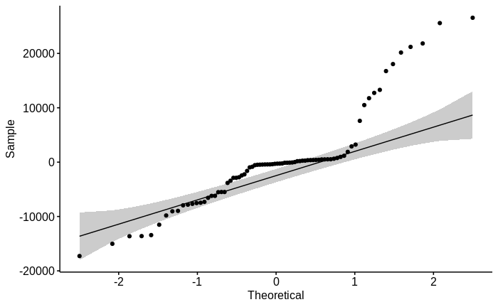

```r
model  <- lm(num_of_packets ~ slam_offloaded*navigation_offloaded*obj_recognition_offloaded, data = data)
ggqqplot(residuals(model))
```

```r
shapiro_test(residuals(model)) %>%
  add_significance()
```

| variable | statistic | p.value | p.value.signif |
| --- | --- | --- | --- |
| residuals(model) | 0.8694231 | 7.727895e-07 | **** |

```r
model_without_outliers  <- lm(num_of_packets ~ slam_offloaded*navigation_offloaded*obj_recognition_offloaded, data = data_without_outliers)
shapiro_test(residuals(model_without_outliers)) %>%
  add_significance()
```

| variable | statistic | p.value | p.value.signif |
| --- | --- | --- | --- |
| residuals(model_without_outliers) | 0.868278 | 9.115297e-07 | **** |

we get very similar results that lead to the conclusion that normality of residuals is indeed not satisfied.

## Normality assumption by each group

The other way to check normality is by analyzing if samples for each possible treatment combination are normally distributed:

```r
data %>%
  group_by(slam_offloaded, navigation_offloaded, obj_recognition_offloaded) %>%
  shapiro_test(num_of_packets) %>%
  add_significance()
```

| slam_offloaded | navigation_offloaded | obj_recognition_offloaded | variable | statistic | p | p.signif |
| --- | --- | --- | --- | --- | --- | --- |
| false | false | false | num_of_packets | 0.9583004 | 0.766332666 | ns |
| false | false | true | num_of_packets | 0.8830610 | 0.141464271 | ns |
| false | true | false | num_of_packets | 0.8999570 | 0.218858358 | ns |
| false | true | true | num_of_packets | 0.7810302 | 0.008521320 | ** |
| true | false | false | num_of_packets | 0.8681233 | 0.095048902 | ns |
| true | false | true | num_of_packets | 0.7277251 | 0.001911857 | ** |
| true | true | false | num_of_packets | 0.8618255 | 0.080182998 | ns |
| true | true | true | num_of_packets | 0.8359196 | 0.039421448 | * |

Shapiro-Wilk test per each group yields p-value higher than `0.05` for most of the groups, except for the three groups where navigation and object recognition are offloaded and SLAM is not (`p = 0.008`), SLAM and object recognition are offloaded and navigation is not (`p = 0.002`) and when all three functionalies are offloaded (`p = 0.039`). If we execute the test on the dataset without extreme outliers:

```r
data_without_outliers %>%
  group_by(slam_offloaded, navigation_offloaded, obj_recognition_offloaded) %>%
  shapiro_test(num_of_packets) %>%
  add_significance()
```

| slam_offloaded | navigation_offloaded | obj_recognition_offloaded | variable | statistic | p | p.signif |
| --- | --- | --- | --- | --- | --- | --- |
| false | false | false | num_of_packets | 0.9583004 | 0.766332666 | ns |
| false | false | true | num_of_packets | 0.8830610 | 0.141464271 | ns |
| false | true | false | num_of_packets | 0.8999570 | 0.218858358 | ns |
| false | true | true | num_of_packets | 0.7810302 | 0.008521320 | ** |
| true | false | false | num_of_packets | 0.8681233 | 0.095048902 | ns |
| true | false | true | num_of_packets | 0.7422632 | 0.004409107 | ** |
| true | true | false | num_of_packets | 0.9255020 | 0.439725888 | ns |
| true | true | true | num_of_packets | 0.8359196 | 0.039421448 | * |

the conclusions from Shapiro-Wilk test results remain the same. The QQ-plots per group are depicted below, where most of the data points seem to be aligned with the reference line, with the exception of three groups that were concluded as not normally distributed in the Shapiro-Wilk test:

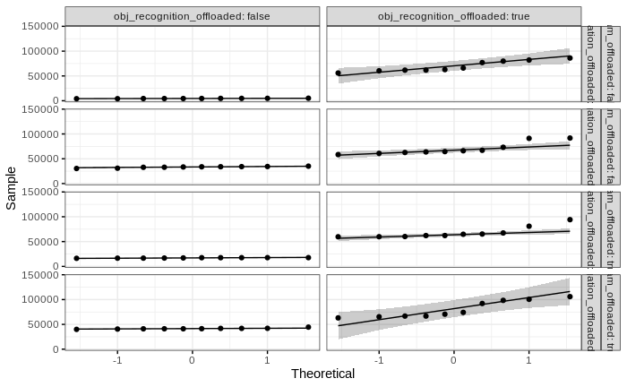

```r
ggqqplot(data, "num_of_packets", ggtheme = theme_bw()) +
  facet_grid(slam_offloaded + navigation_offloaded ~ obj_recognition_offloaded, labeller = "label_both")
```

## Homogeneity of variance assumption

Homogeneity of variance assumption can be checked via Levene’s test:

```r
data %>%
  levene_test(num_of_packets ~ slam_offloaded*navigation_offloaded*obj_recognition_offloaded) %>%
  add_significance()
```

| df1 | df2 | statistic | p | p.signif |
| --- | --- | --- | --- | --- |
| 7 | 72 | 5.292133 | 6.547279e-05 | **** |

Since the p-value is lower than `0.05`, the result of the Levene’s test is statistically significant, hence the null hypothesis stating that homogeneity of variance holds is rejected. If we compute the Levene’s test on dataset without extreme outliers:

```r
data_without_outliers %>%
  levene_test(num_of_packets ~ slam_offloaded*navigation_offloaded*obj_recognition_offloaded) %>%
  add_significance()
```

| df1 | df2 | statistic | p | p.signif |
| --- | --- | --- | --- | --- |
| 7 | 70 | 6.066421 | 1.502651e-05 | **** |

we can draw the same conclusion - homogeneity of variance assumption is not satisfied. With the disputable normality constraint and no homogeneity of variance, we need to turn to non-parametric alternative of three-way ANOVA - permutation test.

# Permutation test

Execution of permutation test yields the following result:

```r
summary(aovp(num_of_packets ~ slam_offloaded*navigation_offloaded*obj_recognition_offloaded, data = data, perm="Prob", maxIter=500000, nCycle=100, Ca=0.001))
```

```
[1] "Settings:  unique SS "
Component 1 :
                                                              Df   R Sum Sq  R Mean Sq  Iter  Pr(Prob)
slam_offloaded                                                 1 1.0991e+09 1.0991e+09 5e+05  0.000858 ***
navigation_offloaded                                           1 5.5103e+09 5.5103e+09 5e+05 < 2.2e-16 ***
slam_offloaded:navigation_offloaded                            1 8.1110e+07 8.1110e+07 5e+05  0.327492
obj_recognition_offloaded                                      1 4.5546e+10 4.5546e+10 5e+05 < 2.2e-16 ***
slam_offloaded:obj_recognition_offloaded                       1 1.8533e+08 1.8533e+08 5e+05  0.137318
navigation_offloaded:obj_recognition_offloaded                 1 1.9774e+09 1.9774e+09 5e+05 < 2.2e-16 ***
slam_offloaded:navigation_offloaded:obj_recognition_offloaded  1 3.3059e+08 3.3059e+08 5e+05  0.051100 .
Residuals                                                     72 6.0660e+09 8.4249e+07
---
Signif. codes:  0 ‘***’ 0.001 ‘**’ 0.01 ‘*’ 0.05 ‘.’ 0.1 ‘ ’ 1
```

Test results show that the main effects are significant for all three independent variables, but there is also a significant two-way interaction between navigation and object recognition. If we compare these results with three-way ANOVA results, that is considered as *robust* when sample sizes are equal for each group:

```r
data %>%
  anova_test(num_of_packets ~ slam_offloaded*navigation_offloaded*obj_recognition_offloaded)
```

```
Coefficient covariances computed by hccm()
```

```
ANOVA Table (type II tests)

                                                         Effect DFn DFd       F        p p<.05   ges
1                                                slam_offloaded   1  72  13.046 5.59e-04     * 0.153
2                                          navigation_offloaded   1  72  65.404 1.05e-11     * 0.476
3                                     obj_recognition_offloaded   1  72 540.603 3.34e-35     * 0.882
4                           slam_offloaded:navigation_offloaded   1  72   0.963 3.30e-01       0.013
5                      slam_offloaded:obj_recognition_offloaded   1  72   2.200 1.42e-01       0.030
6                navigation_offloaded:obj_recognition_offloaded   1  72  23.470 7.06e-06     * 0.246
7 slam_offloaded:navigation_offloaded:obj_recognition_offloaded   1  72   3.924 5.10e-02       0.052
```

we see that the conclusions are very similar to those drawn from the permutation test and the obtained p-values are very similar. The eta-squared effect sizes are:

```r
res.aov <- aov(num_of_packets ~ slam_offloaded*navigation_offloaded*obj_recognition_offloaded, data = data)
eta_squared(res.aov)
```

```
                                               slam_offloaded                                          navigation_offloaded
                                                  0.018079480                                                   0.090636154
                                    obj_recognition_offloaded                           slam_offloaded:navigation_offloaded
                                                  0.749162007                                                   0.001334146
                     slam_offloaded:obj_recognition_offloaded                navigation_offloaded:obj_recognition_offloaded
                                                  0.003048490                                                   0.032525109
slam_offloaded:navigation_offloaded:obj_recognition_offloaded
                                                  0.005437824
```

## Pairwise comparisons for significant navigation_offloaded:obj_recognition_offloaded two-way interaction

Since we have a significant two-way interaction between navigation and object recognition, we need to perform multiple pairwise comparison to determine which group means are different. We will use estimated marginal means test for this purpose with Bonferroni adjustment. We will group the results by object recognition, since the main effect of object recognition is greater than the one of navigation, according to three-way ANOVA results:

```r
data %>%
  group_by(obj_recognition_offloaded) %>%
  emmeans_test(num_of_packets ~ navigation_offloaded, p.adjust.method = "bonferroni", detailed = TRUE)
```

|  | obj_recognition_offloaded | term | .y. | group1 | group2 | null.value | estimate | se | df | conf.low | conf.high | statistic | p | p.adj | p.adj.signif |
| --- | --- | --- | --- | --- | --- | --- | --- | --- | --- | --- | --- | --- | --- | --- | --- |
| 1 | false | navigation_offloaded | num_of_packets | false | true | 0 | -26541.85 | 3195.834 | 76 | -32906.90 | -20176.7959 | -8.305142 | 2.865513e-12 | 2.865513e-12 | **** |
| 2 | true | navigation_offloaded | num_of_packets | false | true | 0 | -6655.30 | 3195.834 | 76 | -13020.35 | -290.2459 | -2.082493 | 4.066240e-02 | 4.066240e-02 | * |

We can see that offloading navigation has a significant effect on the total number of network packets when object recognition is either offloaded and not.

# Results

In the box plot below, we can indeed see that when object recognition is both offloaded and not, the total number of network packets is higher when navigation is offloaded. However, when object recognition is executed on-board, the effect of offloading navigation on the total number of packets seems much larger. Finally, if we compare the means of two groups on the left and right, when object recognition is not offloaded and offloaded, we can see that offloading object recognition does have an enormous overall effect on the total number of network packets:

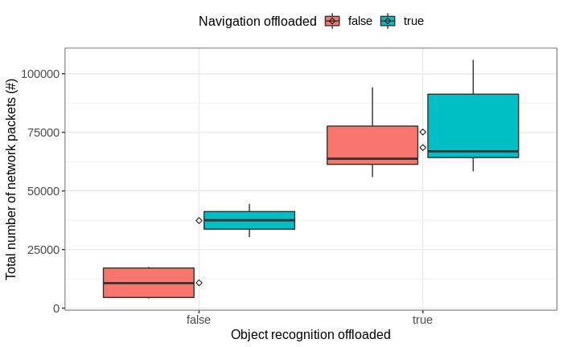

```r
#pdf(file = "../../figures/unknown_map_experiment/number-of-packets-1.pdf")

ggplot(data, aes(x = obj_recognition_offloaded, y = num_of_packets, fill = navigation_offloaded)) +
  theme_bw() +
  geom_boxplot(width = 0.9, outlier.size = 0.5) +
  stat_summary(fun = mean, color = 'black', geom = 'point', shape = 5) +
  labs(x = "Object recognition offloaded", y = "Total number of network packets (#)") +
  guides(fill=guide_legend(title="Navigation offloaded")) +
  theme(
    axis.title.x = element_text(size = 12, family = 'sans'),
    axis.title.y = element_text(size = 12, family = 'sans'),
    axis.text.x = element_text(size = 11, family = 'sans'),
    axis.text.y = element_text(size = 11, family = 'sans'),
    legend.title = element_text(size = 12, family = 'sans'),
    legend.text = element_text(size = 11, family = 'sans'),
    legend.position = "top"
  )
```

```r
#dev.off()
```

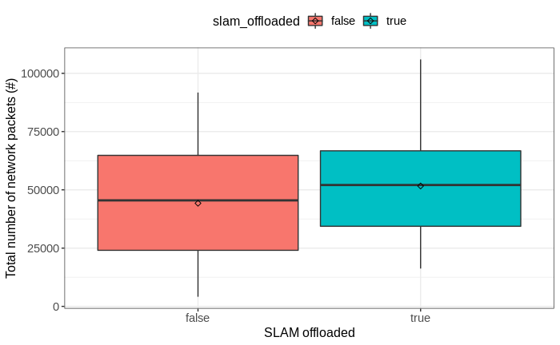

```r
#pdf(file = "../../figures/unknown_map_experiment/number-of-packets-2.pdf")

ggplot(data, aes(x = slam_offloaded, y = num_of_packets, fill = slam_offloaded)) +
  theme_bw() +
  geom_boxplot(width = 0.9, outlier.size = 0.5) +
  stat_summary(fun = mean, color = 'black', geom = 'point', shape = 5) +
  labs(x = "SLAM offloaded", y = "Total number of network packets (#)") +
  theme(legend.position = "none") +
  theme(
    axis.title.x = element_text(size = 12, family = 'sans'),
    axis.title.y = element_text(size = 12, family = 'sans'),
    axis.text.x = element_text(size = 11, family = 'sans'),
    axis.text.y = element_text(size = 11, family = 'sans'),
    legend.title = element_text(size = 12, family = 'sans'),
    legend.text = element_text(size = 11, family = 'sans'),
    legend.position = "top"
  )
```

```r
#dev.off()
```

From the boxplot above, we can see that offloading SLAM does yield an increase in the number of network packets when SLAM is offloaded.